# Data visualization with ggplot2

## Chapter 4 - Themes

### Section 1 - Themes from scratch

- Controls all non-data ink, i.e. visual elements not part of the data
- Three types
  - Text -> `element_text()`
  - Line -> `element_line()`
  - Rectangle -> `element_rect()`

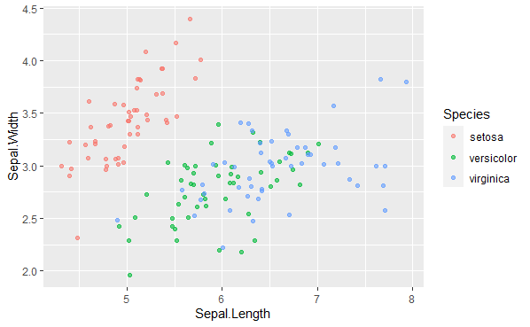

#### Text elements

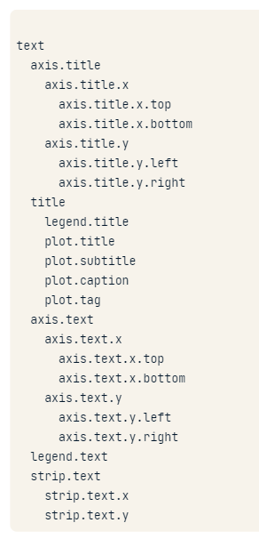

Plot text elements

#### Adjusting theme elements

```r
ggplot(iris, aes(x = Sepal.Length, y = Sepal.Width, color = Species)) +
  geom_jitter(alpha = 0.6) +
  theme(axis.title = element_text(color = "blue"))  # Changes the axis font colours to blue
```

#### Line elements

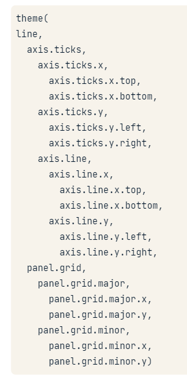

Plot line elements

#### Rect elements

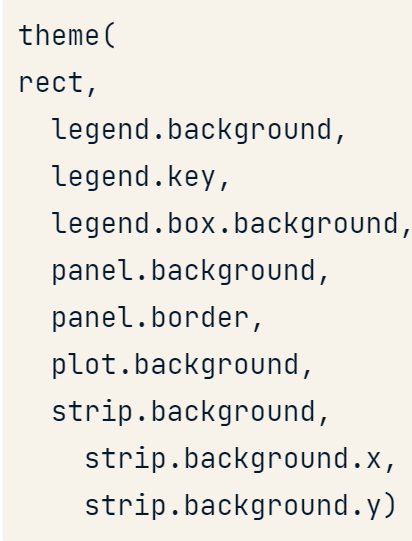

Rectangle elements

#### Hierarchical naming reflects inheritance rules

- If we change text using an upstring argument, all downstream text will be affected

#### `element_blank()`

- Can be used to remove any item

#### Modifying whitespace

- Whitespace - all non-visible margins and spacing in the plot
- To set a single whitespace value, use `unit(x, unit)` where `x` is the amount and `unit` is the unit of measure
- Borders require you to set 4 positions, so use `margin(top, right, bottom, left, unit)`
  - To remember the order think TRouBLe
- Default unit is `pt` (points), which scales well with text. Other options include “cm”, “in” and “lines” (of text)

### Section 2 - Theme Flexibility

#### Ways to use themes

1. From scratch
2. Theme layer object
3. Built-in themes - ggplot2 or ggthemes packages
4. Built-in themes from other packages
5. Update/set default theme

#### Defining theme objects

- Useful when you have many plots
- Provides consistency in style
- Apply a specific theme everywhere

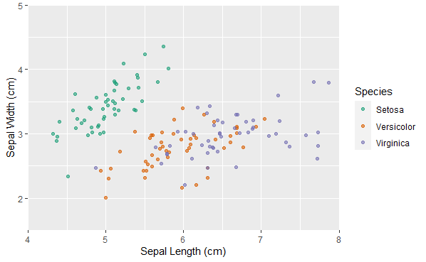

#### Defining theme objects

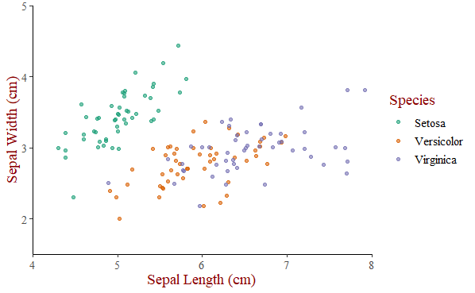

#### Defining theme objects

- Saving layer as object

```r
theme_iris <- theme(text = element_text(family = "serif", size = 14),
          rect = element_blank(),
          panel.grid = element_blank(),
          title = element_text(color = "#8b0000"),
          axis.line = element_line(color = "black"))
```

#### Reusing theme objects

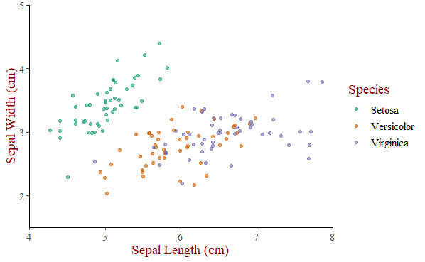

#### Reusing theme objects

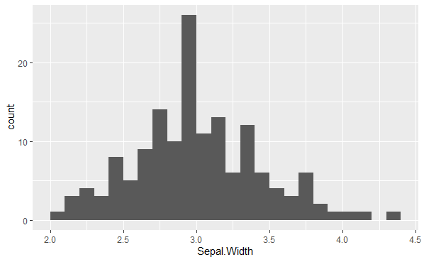

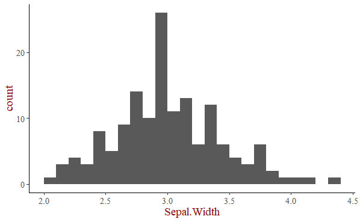

- You can add a theme as well as amend specific elements

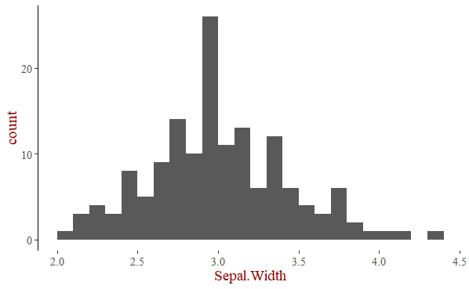

#### Using built-in themes

- Use `theme_*()` functions to access built-in themes

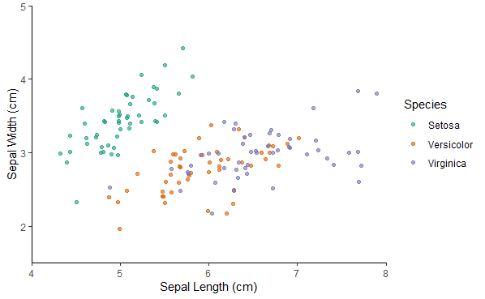

- Can modify any specific theme element

#### The ggthemes package

- Use the ggthemes package for more functions
- tufte - removes all non-data ink and sets font to serif

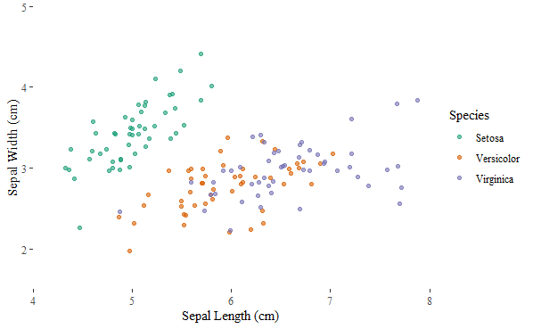

#### Updating themes

- Updating done with `theme_update` function
- Updates default and saves to the object original

```r
original <- theme_update(text = element_text(family = "serif", size = 14),
                        rect = element_blank(),
                        panel.grid = element_blank(),
                        title = element_text(color = "#8b0000"),
                        axis.line = element_line(color = "black"))
```

#### Setting themes

```r
theme_set(original)
```

#### Built-in themes

- Out of the box solutions
  - `theme_gray()` - default
  - `theme_bw()` - useful when you use transparency
  - `theme_classic()` - is more traditional
  - `theme_void()` - removes everything but the data

#### Exploring ggthemes

- `theme_fivethirtyeight()`
- `theme_tufte()`
- `theme_wsj()`

#### Setting themes

- Reusing a theme across many plots helps to provide a consistent style. Options for doing this:
  1. Assign the theme to a variable, and add it to each plot
  2. Set your theme as the default using `theme_set()`

### Section 3 - Effective explanatory plots

#### First explanatory plots - distributions

```r
ggplot(gm2007_full_arranged, aes(index, lifeExp)) +
  geom_point()
```

[output not shown]

- Removing non-data ink makes for a great plot
- Adding a threshold line helps to orientate the viewer
- `geom_curve()` - good for joining curved lines, e.g. adding little arrows on plots
- `geom_segment()` adds line segments - aesthetics - `xend` and `yend`
- `geom_text()` - adds labels
- `geom_vline()` - adds vertical lines

# Intermediate data visualisation with ggplot2

## Chapter 1 - Intermediate data visualisation with ggplot2

### Section 1 - Stats with geoms

#### Statistics layer

- Two categories of function
  - Called within a geom
  - Called independently
- `stats_`

#### geom_ <-> stat_

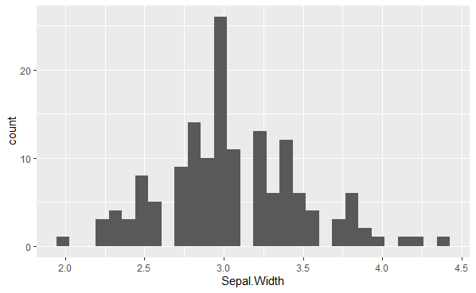

- Could have produced the same result if we had used `geom_bar()`

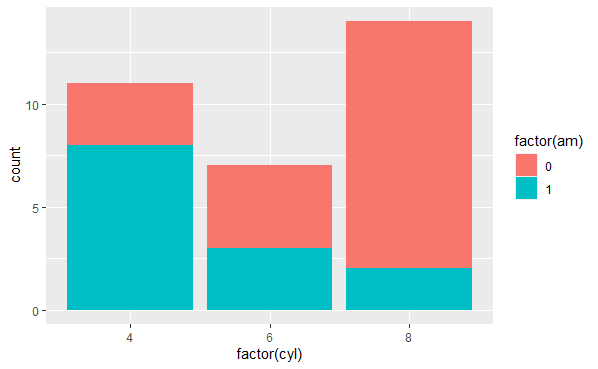

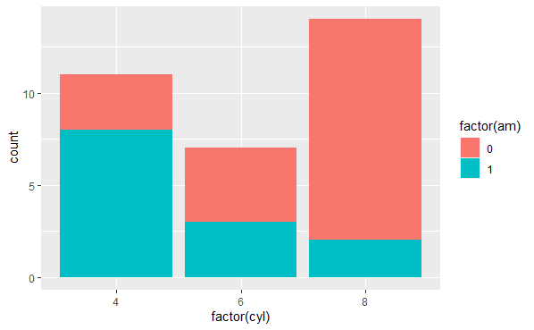

- `geom_bar()` calls `stat_count()` under the hood and vice versa

#### The geom_/stat_ connection

- `stat_bin()` -> `geom_histogram()`, `geom_freqpoly()`
- `stat_count()` -> `geom_bar()`
- `stat_smooth()` -> `geom_smooth()`
- `stat_boxplot()` -> `geom_boxplot()` – useful for summarising data
- `stat_bindot()` -> `geom_dotplot()` – useful for v. large datasets
- `stat_bin2d()` -> `geom_bin2d()` – useful for v. large datasets
- `stat_binhex()` -> `geom_hex()`
- `stat_contour()` -> `geom_contour()` – useful for v. large datasets
- `stat_quantile()` -> `geom_quantile()`
- `stat_sum()` -> `geom_count()`
- Generally don’t have to call the functions directly

#### `stat_smooth()`

- Can be accessed with `geom_smooth()`

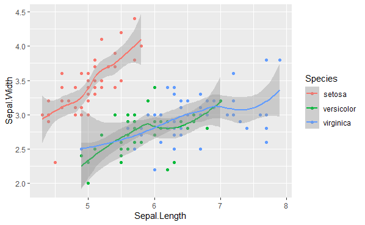

- Standard error is shown as a grey ribbon behind smooth is by default 95% CI
- Can remove by setting `se` arg to FALSE

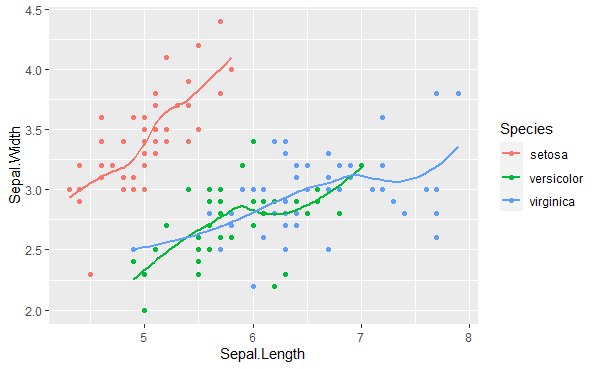

- Message: "geom_smooth() using method = ‘loess’ and formula ‘y ~ x’
- Loess - non-parametric smoothing algorithm, used when n<1000
- Works by calculating a weighted mean, by passing a sliding window along the x-axis and is a valuable tool in exploratory data analysis
- Span argument controls the degree of smoothing
  - `geom_smooth(span = 0.4)` - size of sliding window, smaller spans are more noisy

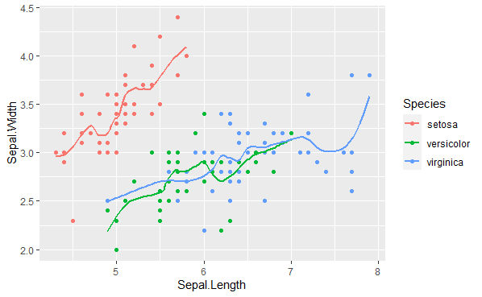

- The method argument can also define parametric models, such as “lm”, “glm”, “rlm” and “gam”
- Where n>1000, the method defaults to “gam”

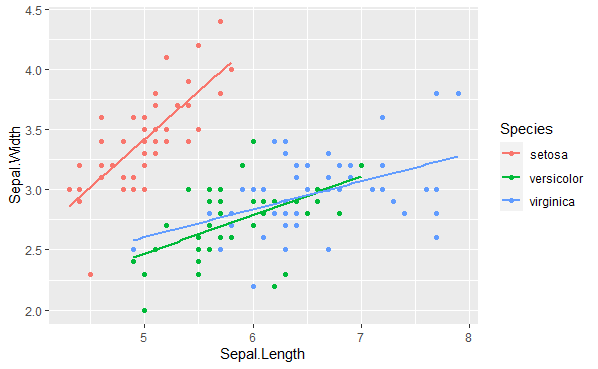

- In both the “loess” and “lm” examples, the model is calculated on groups defined by color

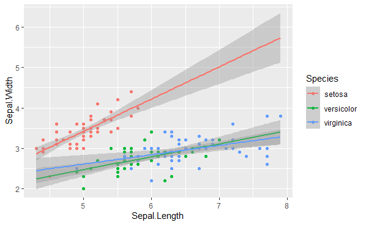

- By default, each model is bound to the limits of its own group, but for parametric methods, we can use the full range argument to make predictions over the full-range - the error increases the further away from our data set we attempt to define an estimate
- Smoothing can be accessed using the geom_smooth function or the stat_smooth function
- LOESS isn’t great on small sections of data - default span is 0.9. A lower span will result in a better fit, but risks overfitting

#### Grouping variables

- `group` aesthetic is invisible
- Setting `group = 1` will reduce all color groupings (for example) into a single group
  - Can add it to the `stat_smooth` function, within `aes`

### Section 2 - Stats: sum and quantile

#### Causes of overplotting and solutions

1. Large datasets -> alpha-blending, hollow circles, point size
2. Aligned values on a single axis -> As above, plus change position
3. Low-precision data -> position: jitter
4. Integer data -> position: jitter

#### Plot counts to overcome overplotting

For low-precision and integer data can use `geom_count()` - plots count at each location

#### Jittering may give the wrong impressions

- It may suggest there is more precision than there actually is
- Should always state that you’re using jitter

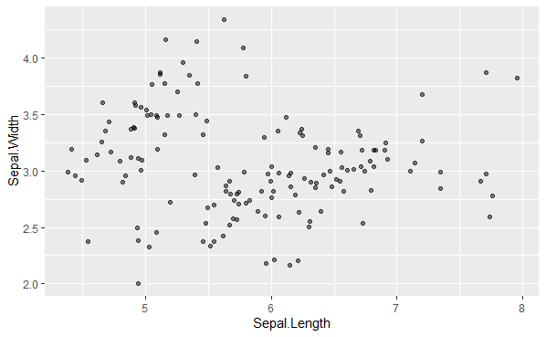

#### `geom_count()`

- Counts the no of obs at observation, then maps onto size (mapped onto area of circle - more easily intuited than radius)
- `stat_sum()` gives the exact same plot

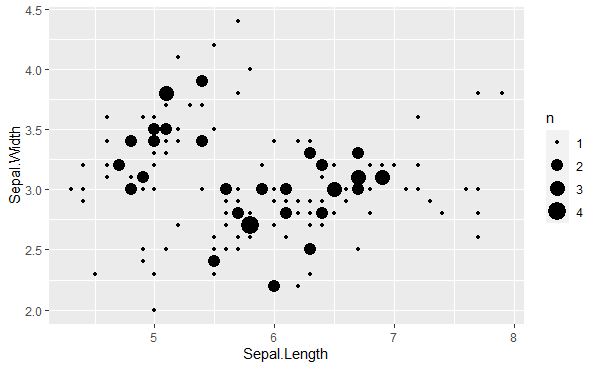

#### Over-plotting can still be a problem¬

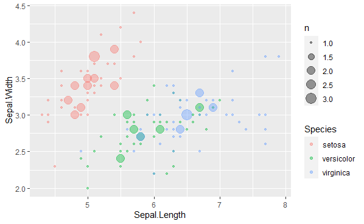

#### geom_quantile()

- Allows us to model quantiles, which are robust, as opposed to linear models, which model the non-robust mean
- We can choose any quantile we’re interested in, such as the median (Q2)
- A typical case of using quantile regression would be when you have heteroscedasticity, where the variance across the predictor variable is not consistent, in which case linear models may not be valid

#### Dealing with heteroscedasticity

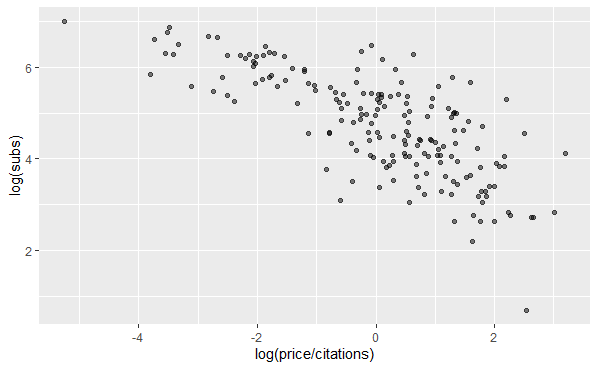

#### Using `geom_quantiles()`

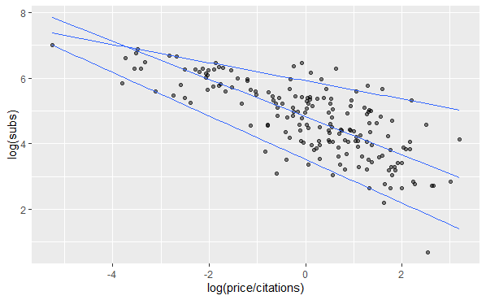

- Quantile predicts the quantile response (e.g. the median) from the explanatory variables

#### Using stat_sum

- `stat_sum()` allows a special variable, `..prop..` to show the *proportion* of values within the dataset

### Section 3 - Stats outside geoms

#### Basic plot

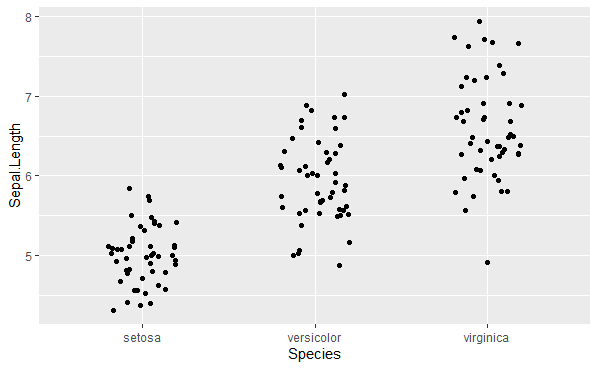

#### Calculating statistics

- A typical way to summarise the data would be to take the mean and standard deviation or the 95% confidence interval

```r
set.seed(123)
xx <- rnorm(100)

# Hmisc
library(Hmisc)
smean.sdl(xx, mult = 1)  # Returns mean +/- one sd as a named vector
```

```
       Mean       Lower       Upper
 0.09040591 -0.82240997  1.00322179
```

#### stat_summary()

- Call mean_sdl using the fun.data argument of the stat_summary function
- By default, we get geom_pointrange(), which requires y, ymin and ymax, excactly what is returned by mean_sdl

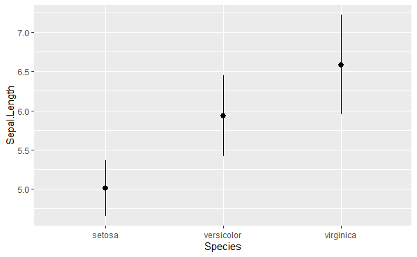

- For errorbars we can just calculate the mean and use “point” as the geom, then we can call mean_sdl using the “errorbar” geom, where can can also set the width of the errorbars

```r
ggplot(iris, aes(x = Species,
                 y = Sepal.Length)) +
  stat_summary(fun.y = mean,
               geom = 'point') +
  stat_summary(fun.data = mean_sdl,
               fun.args = list(mult = 1),
               geom = "errorbar",
               width = 0.1)
```

#### 95% confidence interval

```r
ERR <- qt(0.975, length(xx) - 1) * (sd(xx) / sqrt(length(xx)))
mean(xx)
```

```
[1] 0.09040591
```

```r
mean(xx) + (ERR * c(-1, 1)) # 95% confidence interval
```

```
[1] -0.09071657  0.27152838
```

```r
mean_cl_normal(xx)
```

| y | ymin | ymax |
| --- | --- | --- |
| 0.09040591 | -0.09071657 | 0.2715284 |

#### Other stat_ functions

- stat_summary() - summarize y values at distinct x values
- stat_function() - compute y values from a function of x values
- stat_qq() - perform calculations for a quantile-quartile plot

#### Normal distribution

- For a stat function we can specify any function and produce the theoretical probability distribution as a line

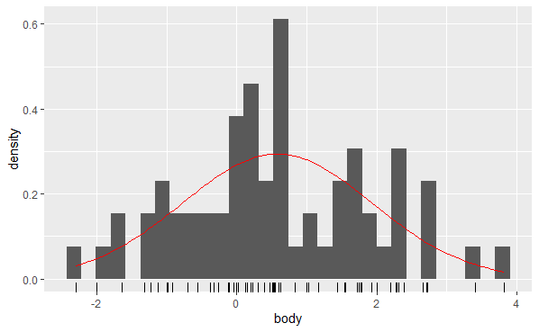

#### QQ plot

- Allow us to compare our data to a distribution
- Plot sample against a theoretical distribution, like the normal and draw a line intersecting the scatter plot at the first and third quartiles
- The closer that our data aligns to this line, the more closely it matches the theoretical distribution in question

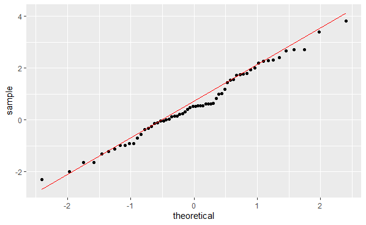

#### Preparations

- Establishing positions and base layer as independent objects will allow us to recycle them easily in many layers, or plots
- Positions:
  - `position_jitter()` - adds jittering, e.g. for points
  - `position_dodge()` - dodges geoms, e.g. bar, col, boxplot etc.
  - `position_jitterdodge()` - jitters and dodges geoms, e.g. points

#### Plotting variations

- *Summary statistics* refer to a combination of *location* (mean or median) and *spread* standard deviation or confidence interval
- These metrics are calculated in `stat_summary()` by passing a function to the `fun.data` argument
- `mean_sdl()` calculates multiples of the standard deviation
- `mean_cl_normal()` calculates the t-corrected 95% confidence interval
- Arguments to the data function are passed to `stat_summary()`’s `fun.args` argument as a list

## Chapter 2 - Coordinates

### Section 1 - The coordinates layer

#### Coordinates layer

- Controls the dimensions of your plot
- Composed of functions named coord_*
  - Most common - `coord_cartesian()`

#### Zooming in

- `coord_cartesian(xlim = ...)`
- Alternatively, can set args in `scale_x_continuous(limits = ...)`
- Or, use `xlim()` or `ylim()`

#### Original plot

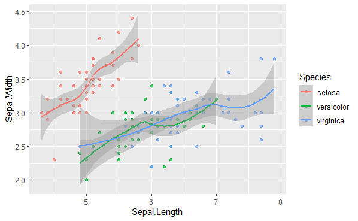

#### `scale_x_continuous()`

- When zooming in using `scale_x_continuous` - we’re presented with some important warning messages
- 95 rows removed - limits were a smaller range than the data

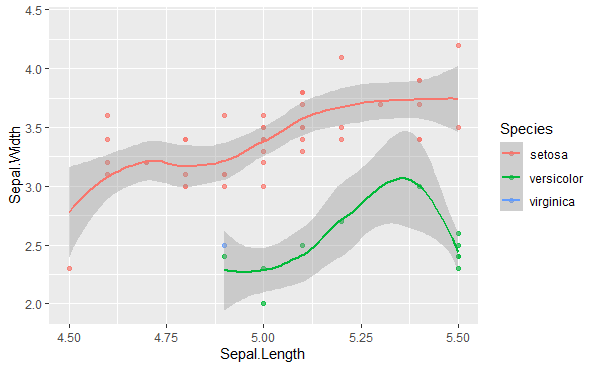

#### `xlim()`

- Quick and dirty - call `xlim()` as a function itself
- Has the same effect

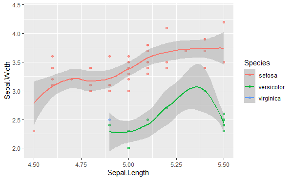

#### `coord_cartesian()` - LOESS curve continues past data - Models look the same in the original plot

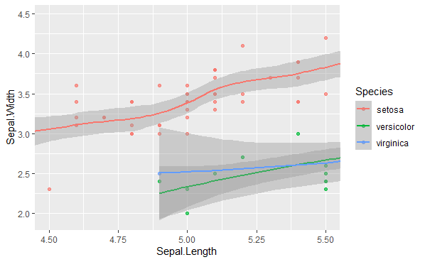

- Changing x and y limits should be used with caution
- Don’t play with them until you’ve seen the data

#### Aspect ratio - Can be achieved with the coordinates layer - Height-to-width aspect ratio - Watch out for deception! - No systematic method - Typically use 1:1 ratio where the units of measure are the same

#### Sunspots

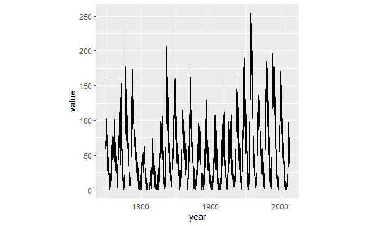

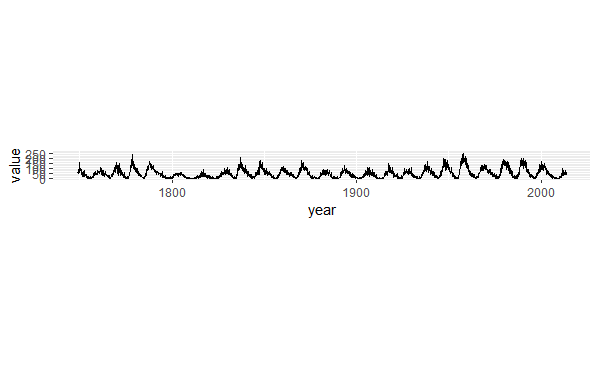

#### Expand and clip

- `expand` sets a buffer margin around the plot, so data and axes don’t overlap. Setting `expand` to 0 draws the axes to the limit of the data
- `clip` decides whether the plot elements that would lie outside the plot panel are displayed or ignored (“clipped”)

### Section 2 - Coordinates vs. scales

- Using the cood layer to plot transformations #### Plot the raw data

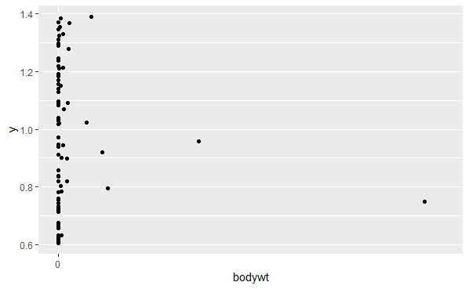

- Data is positively skewed
  - A common transformation for positively skewed data is a natural, base e, logarithm, or the more intuitive common, base10 logarithm

#### Transform the raw data

- We can transform the data before we begin plotting
- Or do it on the fly within the aes function (as below)
- Axis labels are the log transformed values
- E.g. 4 is the log(10) of 10,000 kilograms - can be a bit misleading

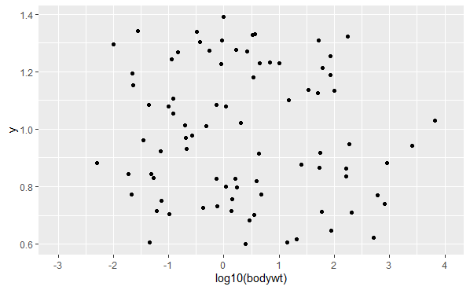

- Stopped with 2mins to go